# Principal Component Analysis

Dataset water.zostera.LT.red.scaled

This dataset contains 124 individuals and 8 variables, 1 qualitative variable is considered as illustrative.

### 1. Inertia distribution

The inertia of the first dimensions shows if there are strong relationships between variables and suggests the number of dimensions that should be studied.

The first two dimensions of PCA express **73.19%** of the total dataset inertia ; that means that 73.19% of the individuals (or variables) cloud total variability is explained by the plane. This percentage is high and thus the first plane represents an important part of the data variability. This value is strongly greater than the reference value that equals **40.13%**, the variability explained by this plane is thus highly significant (the reference value is the 0.95-quantile of the inertia percentages distribution obtained by simulating 849 data tables of equivalent size on the basis of a normal distribution).

From these observations, it is probably not useful to interpret the next dimensions.

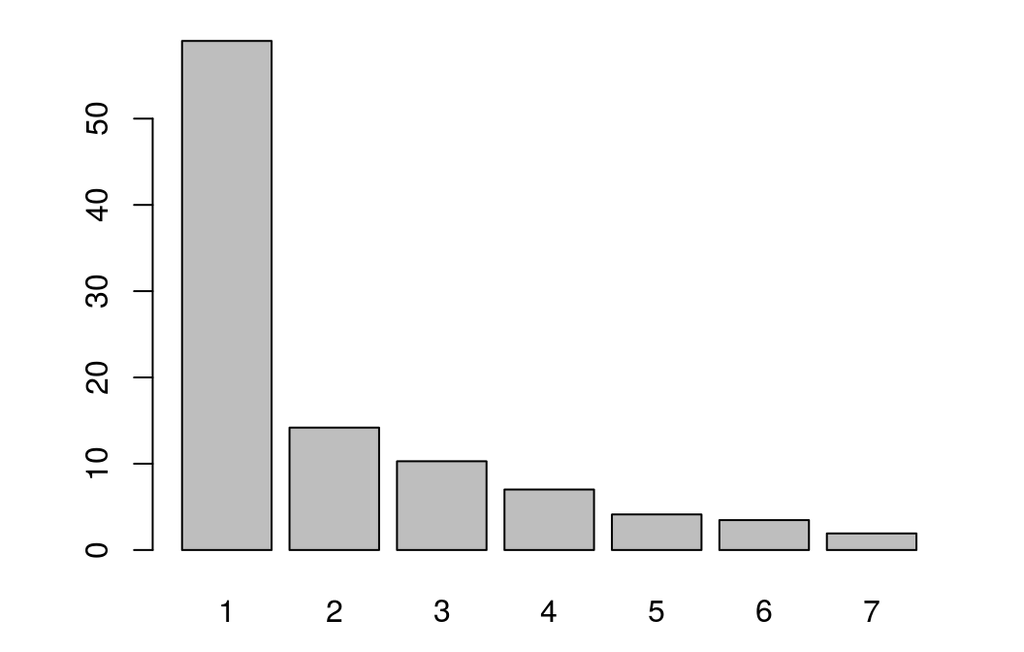

**Figure 1 - Decomposition of the total inertia on the components of the PCA** *The first factor is major: it expresses itself 59% of the data variability.* *Note that in such a case, the variability related to the other components might be meaningless, despite of a high percentage.*

An estimation of the right number of axis to interpret suggests to restrict the analysis to the description of the first 1 axis. These axis present an amount of inertia greater than those obtained by the 0.95-quantile of random distributions (59% against 21.79%). This observation suggests that only this axis is carrying a real information. As a consequence, the description will stand to these axis.

### 2. Description of the dimension 1

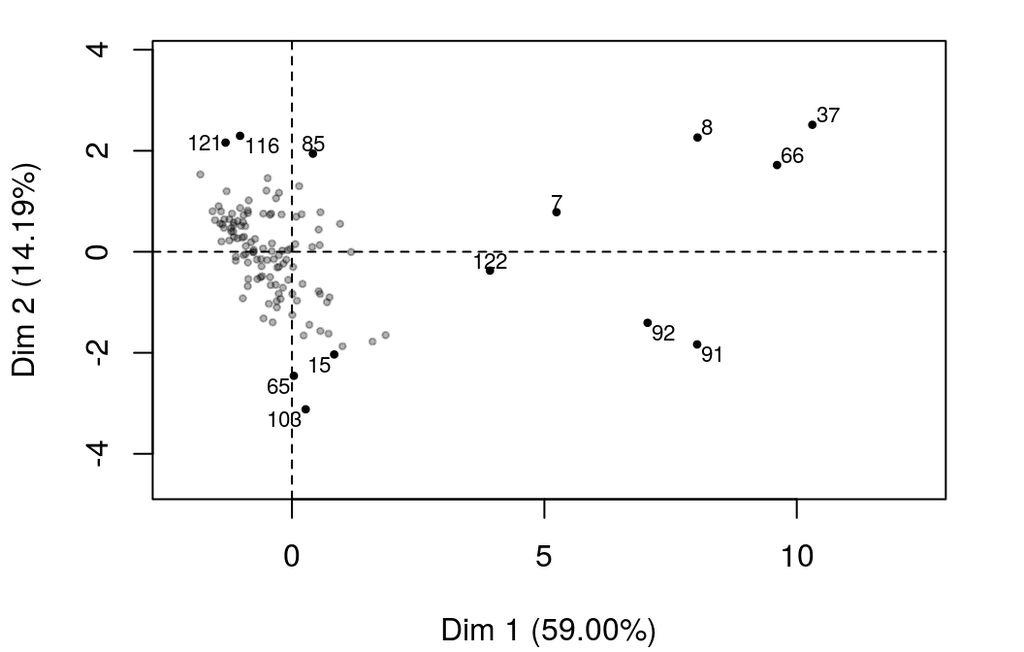

**Figure 2.1 - Individuals factor map (PCA)** *The labeled individuals are those with the higher contribution to the plane construction.*

The Wilks test p-value indicates which variable factors are the best separated on the plane (i.e. which one explain the best the distance between individuals).

```
##   station
## 0.9172989
```

There only is one possible qualitative variable to illustrate the distance between individuals : *station*.

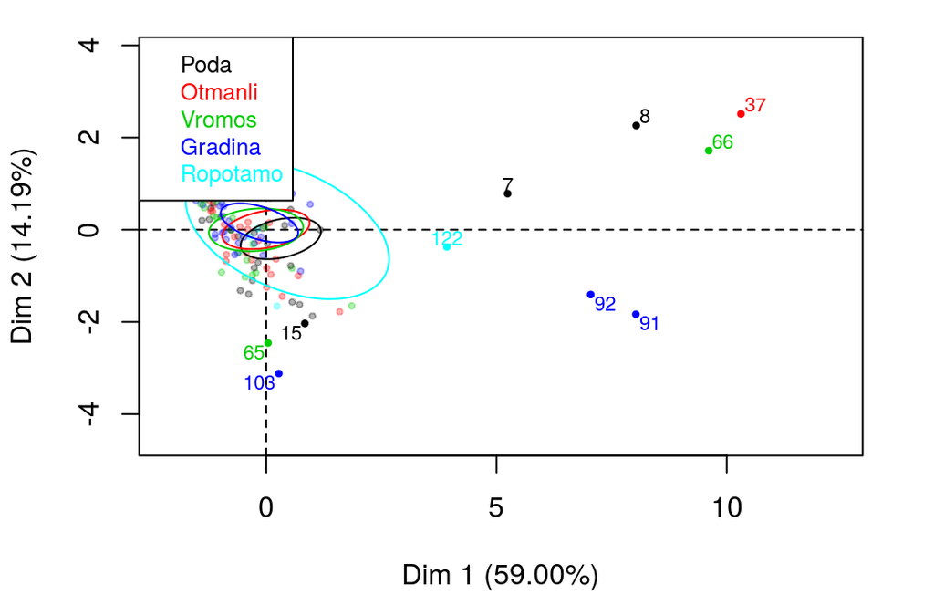

**Figure 2.2 - Individuals factor map (PCA)** *The labeled individuals are those with the higher contribution to the plane construction.* *The individuals are coloured after their category for the variable* station.

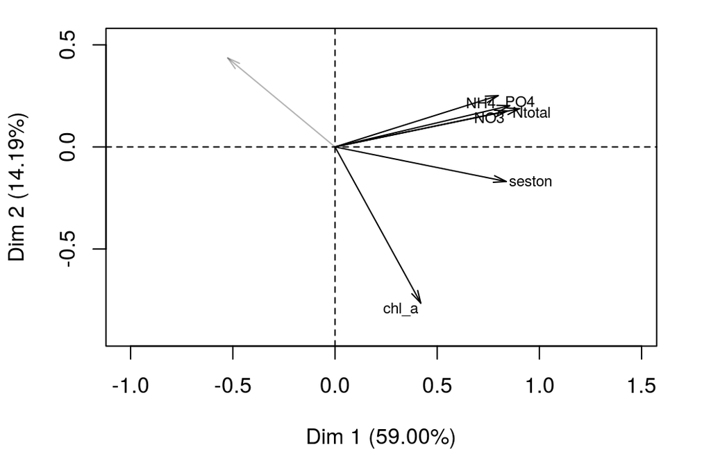

**Figure 2.3 - Variables factor map (PCA)** *The labeled variables are those the best shown on the plane.*

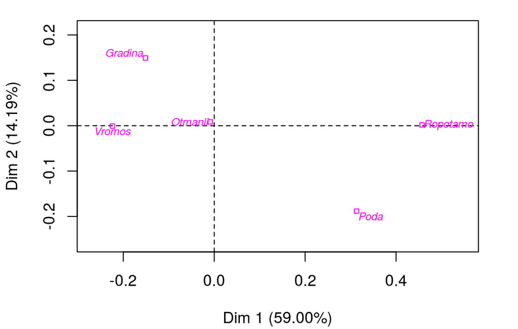

**Figure 2.4 - Qualitative factor map (PCA)** *The labeled factors are those the best shown on the plane.*

The **dimension 1** opposes individuals such as *66*, *37*, *8*, *7*, *92* and *91* (to the right of the graph, characterized by a strongly positive coordinate on the axis) to individuals characterized by a strongly negative coordinate on the axis (to the left of the graph).

The group 2 (characterized by a negative coordinate on the axis) is sharing :

- high values for the variable *secchi*.
- low values for the variables *chl_a*, *seston*, *Ntotal*, *NH4*, *NO3* and *PO4* (variables are sorted from the weakest).

### 3. Classification

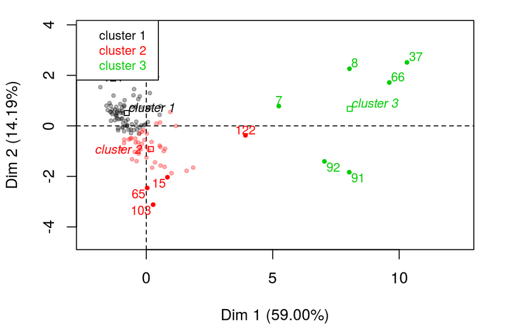

**Figure 3 - Ascending Hierarchical Classification of the individuals.** *The classification made on individuals reveals 3 clusters.*

The **cluster 1** is made of individuals such as *85*, *116* and *121*. This group is characterized by :

- high values for the variable *secchi*.
- low values for the variables *chl_a*, *Ntotal*, *seston*, *NO3*, *PO4* and *NH4* (variables are sorted from the weakest).

The **cluster 2** is made of individuals such as *15*, *65*, *103* and *122*. This group is characterized by :

- high values for the variable *chl_a*.
- low values for the variable *secchi*.

The **cluster 3** is made of individuals such as *7*, *8*, *37*, *66*, *91* and *92*. This group is characterized by :

- high values for the variables *PO4*, *seston*, *NH4*, *NO3*, *Ntotal* and *chl_a* (variables are sorted from the strongest).
- low values for the variable *secchi*.

## Annexes

```r
dimdesc(res, axes = 1:1)
```

```
$Dim.1
$Dim.1$quanti
       correlation      p.value
PO4      0.9064699 1.666586e-47
Ntotal   0.8587396 3.135828e-37
NO3      0.8468131 3.013257e-35
seston   0.8410776 2.362034e-34
NH4      0.8019130 4.568736e-29
chl_a    0.4231112 9.790184e-07
secchi  -0.5474437 4.723126e-11
```

**Figure 4 - List of variables characterizing the dimensions of the analysis.**

```r
res.hcpc$desc.var
```

```
Link between the cluster variable and the quantitative variables
================================================================
            Eta2      P-value
PO4    0.7755565 5.520508e-40
seston 0.6598304 4.651376e-29
chl_a  0.6078921 2.517894e-25
Ntotal 0.5979589 1.143825e-24
NO3    0.5873544 5.526156e-24
NH4    0.5849387 7.866675e-24
secchi 0.2970040 5.503625e-10

Description of each cluster by quantitative variables
=====================================================
$`1`
          v.test Mean in category  Overall mean sd in category Overall sd
secchi  5.116406        0.3697240  1.601122e-17      0.9190456  0.9588299
NH4    -2.496754       -0.1874082  2.792345e-17      0.6692229  0.9959596
PO4    -3.126112       -0.2346483 -4.330863e-17      0.2843996  0.9959596
NO3    -3.487074       -0.2617424 -3.471895e-17      0.4299545  0.9959596
seston -3.877257       -0.2910297 -2.218243e-17      0.3129010  0.9959596
Ntotal -4.148416       -0.3113832 -3.696780e-18      0.5383396  0.9959596
chl_a  -8.637074       -0.6456644 -4.696869e-17      0.4067792  0.9919027
            p.value
secchi 3.114125e-07
NH4    1.253358e-02
PO4    1.771342e-03
NO3    4.883354e-04
seston 1.056409e-04
Ntotal 3.347838e-05
chl_a  5.767106e-18

$`2`
          v.test Mean in category  Overall mean sd in category Overall sd
chl_a   7.620888        0.9030865 -4.696869e-17      0.7887327  0.9919027
secchi -3.237179       -0.3708199  1.601122e-17      0.6371716  0.9588299
            p.value
chl_a  2.519369e-14
secchi 1.207175e-03

$`3`
          v.test Mean in category  Overall mean sd in category Overall sd
PO4     9.753429         3.884292 -4.330863e-17      1.6805007  0.9959596
seston  8.876287         3.534971 -2.218243e-17      2.0521318  0.9959596
NH4     8.479403         3.376912  2.792345e-17      0.8978064  0.9959596
NO3     8.404781         3.347194 -3.471895e-17      1.1267127  0.9959596
Ntotal  8.346825         3.324114 -3.696780e-18      1.5320814  0.9959596
chl_a   2.729100         1.082434 -4.696869e-17      1.1375001  0.9919027
secchi -4.478744        -1.717159  1.601122e-17      0.1884316  0.9588299
            p.value
PO4    1.783406e-22
seston 6.912919e-19
NH4    2.263529e-17
NO3    4.286615e-17
Ntotal 7.012230e-17
chl_a  6.350738e-03
secchi 7.508354e-06
```

**Figure 5 - List of variables characterizing the clusters of the classification.**